# Lab 7

## WorldClim data

WorldClim (www.worldclim.org) provides current, historical, and future predicted climate data for use in ecological and GIS studies. I downloaded several files from that site for you to work with today.

```r
# Average June temperature 1970-2000, deg. C
juneTempsFile <- "wc2.0_10m_tavg_06.tif"
# Average June temperature 1960-1990, deg. C * 10
juneTempsFile2 <- "tmean6.bil"
# Average annual temperature 1970-2000, deg. C
avgTempFile <- "wc2.0_bio_10m_01.tif"
```

The packages “raster” and “rgdal” can be used for importing and manipulating this sort of data.

```r
install.packages("raster")
install.packages("rgdal")
```

```r
library(raster)
library(rgdal)
```

We can preview the data with `plot`.

```r
library(viridis)
```

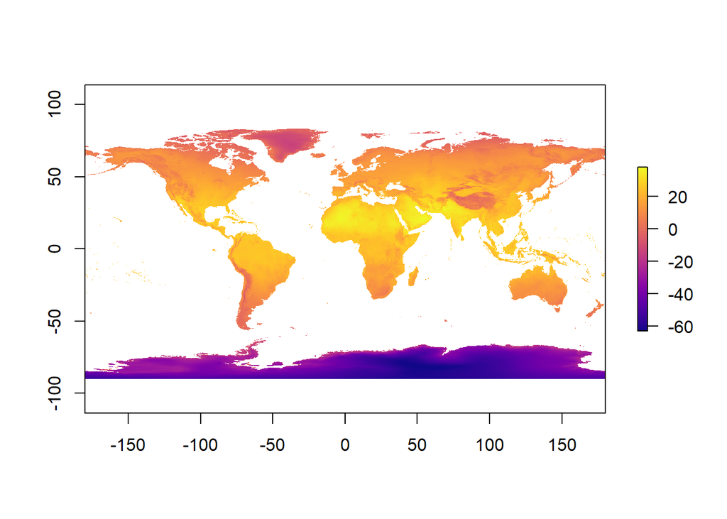

```r
plot(raster(juneTempsFile), col = plasma(255))
```

## Number formats in the WorldClim datasets

For each of the three file names, use the function `GDALinfo` to learn more about the file’s contents. Pay particular attention to the format listed under “GDtype”.

**Question 1 to turn in:** What does the number after “Int” or “Float” mean? Which file(s) contain numbers in a format that matches one of the formats in the R base? Given the number format of “tmean6.bil”, why do you think that file contains degrees Celsius multiplied by ten, while the other files just contain degrees Celsius without a multiplier?

```r
# The number indicates how many bits the format uses.  "wc2.0_bio_10m_01.tif"
# uses 64-bit floats (double-precision floating point numbers), which is the
# 'numeric' class and 'double' type in the R base.  The other two files use
# formats not found in the R base; 32-bit floats (single-precision floating
# point) for "wc2.0_10m_tavg_06.tif" and 16-bit integers for
# "tmean6.bil".  Because "tmean6.bil" stores temperatures in an integer format,
# by multipling by ten it allows temperatures to be stored precisely in
# 1/10 degree increments.

GDALinfo(juneTempsFile)
```

```
## rows        1080
## columns     2160
## bands       1
## lower left origin.x        -180
## lower left origin.y        -90
## res.x       0.1666667
## res.y       0.1666667
## ysign       -1
## oblique.x   0
## oblique.y   0
## driver      GTiff
## projection  +proj=longlat +datum=WGS84 +no_defs
## file        wc2.0_10m_tavg_06.tif
## apparent band summary:
##    GDType hasNoDataValue NoDataValue blockSize1 blockSize2
## 1 Float32           TRUE    -3.4e+38          1       2160
## apparent band statistics:
##      Bmin     Bmax Bmean Bsd
## 1 -63.068 38.39325     1   1
## Metadata:
## AREA_OR_POINT=Area
```

```r
GDALinfo(juneTempsFile2)
```

```
## rows        900
## columns     2160
## bands       1
## lower left origin.x        -180
## lower left origin.y        -60
## res.x       0.1666667
## res.y       0.1666667
## ysign       -1
## oblique.x   0
## oblique.y   0
## driver      EHdr
## projection  +proj=longlat +datum=WGS84 +no_defs
## file        tmean6.bil
## apparent band summary:
##   GDType hasNoDataValue NoDataValue blockSize1 blockSize2
## 1  Int16           TRUE       -9999          1       2160
## apparent band statistics:
##   Bmin Bmax Bmean Bsd
## 1 -116  384    NA  NA
```

```r
GDALinfo(avgTempFile)
```

```
## rows        1080
## columns     2160
## bands       1
## lower left origin.x        -180
## lower left origin.y        -90
## res.x       0.1666667
## res.y       0.1666667
## ysign       -1
## oblique.x   0
## oblique.y   0
## driver      GTiff
## projection  +proj=longlat +datum=WGS84 +no_defs
## file        wc2.0_bio_10m_01.tif
## apparent band summary:
##    GDType hasNoDataValue NoDataValue blockSize1 blockSize2
## 1 Float64           TRUE   -1.7e+308          1       2160
## apparent band statistics:
##        Bmin     Bmax     Bmean     Bsd
## 1 -53.70207 33.26064 -3.821705 24.1523
## Metadata:
## AREA_OR_POINT=Area
```

## Integer math

Let’s extract the average June temperature from 1960-1990 for the collection locations in our *Miscanthus sinensis* data set from Week 1.

```r
msiyield <- read.csv("Miscanthus_sinensis_yield.csv")
msiXY <- as.matrix(msiyield[,3:2])
colnames(msiXY) <- c("x", "y")
# remove rows without spatial coordinates
msiXY <- msiXY[!is.na(msiXY[,1]), ]

# make raster object for tmean6.bil
juneTempsRaster2 <- raster(juneTempsFile2)
# extract cell numbers
msiCells <- cellFromXY(juneTempsRaster2, msiXY)

# get temperatures
msiJuneTemp <- getValues(juneTempsRaster2)[msiCells]
msiJuneTemp
```

```
##   [1] 207 224 135 135 135 158 158 158 161 161 161 163 152 152 142 142 134
##  [18] 139 139 139 139 148 143 143 143 143 145 145 147 147 144 144 144 144
##  [35] 151 151 138 143 143 130 181 181 181 182 182 142 142 142 143 133 133
##  [52] 133 211 211 211 211 211 219 189 135 135 149 219 219 198 198 204 163
##  [69] 163 141 141 140 140 140 140 140 142 142 147 147 147 146 146 142 142
##  [86] 142 142 142 142 147 147 139 139 139 139 154 154 161 158 150 129 129
## [103] 129 110 110 125 189 189 192 192 174 214 162 212 183 186 200 198 184
## [120] 197 193 171 193 156 192 199 193 173 175 183 193 186 160 210 198 221
## [137] 221 203 210 211 212 211 193 211 209 205 215 210 213 205 213 211 206
## [154] 206 210 221 207 216 216 221 216 216 217 208 218 212 212 217 209 211
## [171] 206 221 221 223 215 214 216 221 223 216 214 212 215 173 211 212 212
## [188] 186 214 206 217 208 175 173 179 183 174 209 205 194 205 212 166 179
## [205] 180 200 208 166 203 179 193 194 173 191 194 178 198 174 173 200 208
## [222] 180 171 171 189 198 180 162 193 207 207 208 199 194 194 190 194 178
## [239] 200 208 206 208 206 211 190 199 212 214 203 206 212 187 214 214 197
## [256] 207 214 221 214 215 178 214 214 214 214 205 205 205 205 205 205 205
## [273] 186 186 205 205 205 205 205 204 204 204 206 206 211 211 211 217 217
## [290] 217 217 217 217 217 217 260 210 190 194 230 214 224 243 248 248 248
## [307] 238 233 233 228 220 244 244 231 219 254 239 190 164 164 182 182 228
## [324] 228 231 225 242 233 231 231 237 228 236 238 217 221 221 177 177 187
## [341] 208 202 215 210 194 181 212 224 211 218 208 248 248 248 231 231 231
## [358] 231 231 231 231 254 249 249 249 231 243 254 263 231 231 234 237 230
## [375] 226 226 220 220 229 261 260 256 235 228 242 242 236 241 246 242 242
## [392] 234 227 239 247 261 261 261 231 257 250 250 235 246 261 261 258 258
## [409] 262 262 262 262 263 263 267 267 267 261 261 279 266 282 287 286 285
## [426] 257 280 271 254 258 268 265 260 258 254 236 236 251 239 254 241 253
## [443] 249 257 254 260 260 197 197 274 274 274 210 197 197 237 185 185 242
## [460] 240 195 220 187 197 197 244 239 232 222 204 188 188 230 243 244 228
## [477] 260 250 258 238 234 245 239 237 212 237 239 245 223 223
```

```r
typeof(msiJuneTemp)
```

```
## [1] "integer"
```

Say you want to convert degrees to growing degrees, so that you can calculate growing degree days. Typically you subtract 10°C from a temperature in order to convert to growing degrees (GD), since many crops will not grow below 10°C. Temperatures below 10°C are also converted to 0 GD, and temperatures above 30°C are capped at 20 GD since most crops do not have increased productivity above that temperature.

- 5°C –> 0 GD
- 10°C –> 0 GD
- 15°C –> 5 GD
- 30°C –> 20 GD
- 35°C –> 20 GD
- etc.

The values that we got from the WorldClim file are integers, indicating temperature times ten. Pretend that we want to keep them that way in order to save memory and processing time.

**Question 2 to turn in:** Make a function to convert degrees Celsius to growing degrees. The output should still be in integer format and still multiplied by ten, like the input.

```r
# function to take temperature, in degrees C times 10, and convert it to
# growing degrees, also in degrees C times 10, in integer format.
growingDegreesTimesTen <- function(temp){
  gd <- temp - 100L
  gd[gd < 0L] <- 0L
  gd[gd > 200L] <- 200L
  return(gd)
}
```

```r
myGD <- growingDegreesTimesTen(msiJuneTemp)
myGD[1:15]
```

```
##  [1] 107 124  35  35  35  58  58  58  61  61  61  63  52  52  42
```

```r
typeof(myGD)
```

```
## [1] "integer"
```

**Hints**

You should be able to keep the numbers in integer format without using `as.integer`.

You can use Boolean indexing to identify and replace values below zero or above 20.

Remember that since everything is mutliplied by 10, you actually are subtracting 100 rather than 10, and capping at 200 rather than 20.

## Package-specific classes

We used some specialized functions to import and examine GIS data. The object storing the data is a specialized class for that type of data. In addition to including function definitions, the `raster` package includes class definitions.

In lecture we talked about how `plot` is a generic function. It must have a method for whatever class we have our GIS data in, since we were able to use `plot` directly on that object.

Try to find the help page for the class, as well as the help page for the `plot` method.

**Question 3 to turn in:** What class is `juneTempsRaster2`? What code pulls up the help page for the `plot` method?

```r
## The class of `juneTempsRaster2` is `"RasterLayer"`.
class(juneTempsRaster2)
```

```
## [1] "RasterLayer"
## attr(,"package")
## [1] "raster"
```

```r
## To get the help page for the `plot` method:
?`plot,Raster,ANY-method`
```

```
## starting httpd help server ... done
```

```r
# or
?`plot,Raster,Raster-method`
```

**Hints**

The class name itself has a “package” attribute indicating what package the class came from. Be sure not to confuse the class name and package name.

The class is a particular type of class called S4, which is a system for package developers to add new classes. So far in lecture we have mostly looked at S3 classes and methods, so the documentation might be slightly different from what you are used to.

To find the help pages, you might begin typing and then look at the auto-complete suggestions.